# Jake’s Trulia Tidy Text Analysis

#### Load packages and data

```r
library(dplyr)
library(readr)
library(stringr)
library(tidyr)
library(tidytext)
library(janitor)
library(ggplot2)
library(lubridate)
library(knitr)
library(viridis)
```

```r
raw_text <- read_csv("trulia_blog_text.csv")
```

### Setup

This is an exploratory data analysis of [Trulia’s Housing Research blog](https://www.trulia.com/blog/trends/). I scraped 142 blog posts from the four members of the Economics and Housing Research team (Ralph McLaughlin, Cheryl Young, Felipe Chacon, and David Weidner).

This post won’t cover the details of the scraping code, but I’ve [posted that too](https://github.com/JakeRuss/trulia-tidytext/blob/master/collect_posts.R), so this analysis is fully reproducible.

```r
# Let's clean up the author names and make it a factor variable
raw_text <- raw_text %>%
  mutate(author = recode(author, ralph       = "Ralph",
                                 cherylyoung = "Cheryl",
                                 fchacon     = "Felipe",
                                 david       = "David"),
         author = factor(author, levels = c("Cheryl", "David", "Felipe", "Ralph")),
         year   = year(blog_date))
```

I’m going to start with some summaries and graphs that will give me a better handle on the overall dataset, and keep an eye out for interesting patterns that could be explored with text analysis.

#### Who has written the most posts?

```r
raw_text %>%
  tabyl(author, sort = TRUE) %>%
  kable(digits = 2)
```

| author | n | percent |
| --- | --- | --- |
| Ralph | 105 | 0.74 |
| Cheryl | 14 | 0.10 |
| Felipe | 13 | 0.09 |
| David | 10 | 0.07 |

Not surprisingly, Ralph, Trulia’s Chief Economist, has the most posts.

#### What does the distribution of blog posts look like over time?

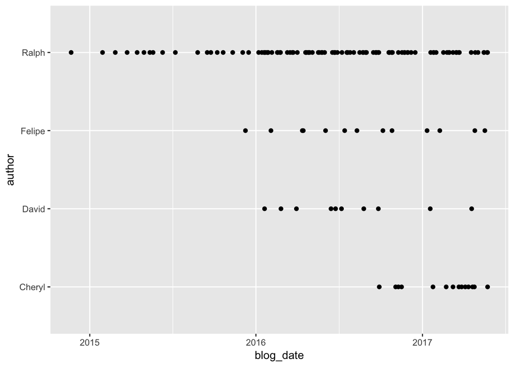

```r
# Visualize post history
raw_text %>%
  ggplot(aes(x = blog_date, y = author)) +
  geom_point()
```

Ralph’s huge lead in the number of blog posts is the result of time and speed. Not only has he been writing posts for Trulia since 2014, but he also posts at a much faster rate than anyone else.

#### What is the average time between posts by author?

```r
raw_text %>%
  group_by(author) %>%
  summarise(n_posts    = n(),
            first_post = min(blog_date),
            last_post  = max(blog_date)) %>%
  mutate(total_days = (last_post - first_post) %>% as.numeric,
         avg_days   = (total_days / n_posts) %>% janitor:::round_half_up(2)) %>%
  kable()
```

| author | n_posts | first_post | last_post | total_days | avg_days |
| --- | --- | --- | --- | --- | --- |
| Cheryl | 14 | 2016-09-28 | 2017-05-24 | 238 | 17.00 |
| David | 10 | 2016-01-20 | 2017-04-19 | 455 | 45.50 |
| Felipe | 13 | 2015-12-09 | 2017-05-18 | 526 | 40.46 |
| Ralph | 105 | 2014-11-21 | 2017-05-24 | 915 | 8.71 |

Since he started writing for Trulia, Ralph has written a new post about every 9 days. However, this calculation doesn’t take into account weekends, so a better estimate is probably every 7 business days.

By this measure, Cheryl takes double the amount of time as Ralph between posts. But, it looks like Ralph’s posting habits changed dramatically at the beginning of 2016, when he became Chief Economist, so let’s look at posting frequency by year.

```r
raw_text %>%
  group_by(author, year) %>%
  summarise(n_posts    = n(),
            first_post = min(blog_date),
            last_post  = max(blog_date)) %>%
  mutate(total_days = (last_post - first_post) %>% as.numeric,
         avg_days   = (total_days / n_posts) %>% janitor:::round_half_up(2)) %>%
  kable()
```

| author | year | n_posts | first_post | last_post | total_days | avg_days |
| --- | --- | --- | --- | --- | --- | --- |
| Cheryl | 2016 | 4 | 2016-09-28 | 2016-11-16 | 49 | 12.25 |
| Cheryl | 2017 | 10 | 2017-01-24 | 2017-05-24 | 120 | 12.00 |
| David | 2016 | 8 | 2016-01-20 | 2016-09-26 | 250 | 31.25 |
| David | 2017 | 2 | 2017-01-18 | 2017-04-19 | 91 | 45.50 |
| Felipe | 2015 | 1 | 2015-12-09 | 2015-12-09 | 0 | 0.00 |
| Felipe | 2016 | 8 | 2016-02-03 | 2016-10-26 | 266 | 33.25 |
| Felipe | 2017 | 4 | 2017-01-11 | 2017-05-18 | 127 | 31.75 |
| Ralph | 2014 | 1 | 2014-11-21 | 2014-11-21 | 0 | 0.00 |
| Ralph | 2015 | 17 | 2015-01-29 | 2015-12-16 | 321 | 18.88 |
| Ralph | 2016 | 67 | 2016-01-07 | 2016-12-16 | 344 | 5.13 |
| Ralph | 2017 | 20 | 2017-01-19 | 2017-05-24 | 125 | 6.25 |

From January 2016 on, Ralph has written a bit more than a post a week, suggesting that his promotion to Chief Econmist represented a meanginful shift in his responsibities at Trulia. David has posted a little slower in 2017, so far, and Cheryl and Felipe have stayed consistent with the rates they established in 2016.

#### How many posts in each category type?

```r
raw_text %>%
  group_by(blog_theme) %>%
  summarise(n = n()) %>%
  arrange(-n) %>%
  kable()
```

| blog_theme | n |
| --- | --- |
| Affordability | 63 |
| Home Buying and Selling | 58 |
| Home Amenities | 9 |
| Housing Policy | 5 |
| Livability | 4 |
| Home Searches | 1 |
| Infographics | 1 |
| Millennials, Gen X and Baby Boomers | 1 |

#### What is the distribution of categories by author?

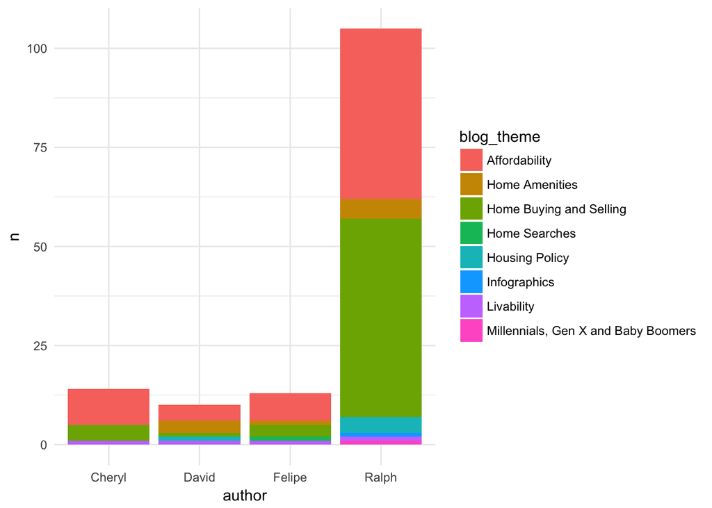

```r
raw_text %>%
  group_by(author, blog_theme) %>%
  summarise(n = n()) %>%
  ggplot(aes(x = author, y = n, fill = blog_theme)) +
  geom_bar(stat = "identity") +
  theme_minimal()
```

Sweet, here we go! I found some patterns that can be explored with text analysis!

#### Testable predictions and a question

- When I look at [tf-idf](https://en.wikipedia.org/wiki/Tf%E2%80%93idf) scores, I expect words associated with housing amenities to show up in David’s text, and policy words to show up in Ralph’s text.
- I suspect Cheryl and Felipe may have similar word usuage patterns given the similarity of their posting categories.
- Which writer brings the most positive outlook to their writing?

### Setup the tidy text data

```r
# Convert blog text to tidy format
tidy_words <- raw_text %>%
  unnest_tokens(word, blog_text)

# Remove "stop words" and count word frequency
author_words <- tidy_words %>%
  anti_join(stop_words, by = "word") %>%
  mutate(is_numeric   = !is.na(as.numeric(word)),
         is_thousands = str_detect(word,
         regex("^(?!0+\\.00)(?=.{1,9}(\\.|$))(?!0(?!\\.))\\d{1,3}(,\\d{3})*(\\.\\d+)?$"))) %>%
  # also remove numeric "words"
  filter(!is_numeric, !is_thousands) %>%
  count(author, word, sort = TRUE) %>%
  ungroup()
total_words <- author_words %>%
  group_by(author) %>%
  summarize(total = sum(n))

author_words <- left_join(author_words, total_words, by = "author")

author_words
```

```
## # A tibble: 9,608 x 4
##    author    word     n total
##    <fctr>   <chr> <int> <int>
##  1  Ralph    home   953 40038
##  2  Ralph   homes   711 40038
##  3  Ralph housing   543 40038
##  4  Ralph markets   450 40038
##  5  Ralph   price   377 40038
##  6  Ralph   month   372 40038
##  7  Ralph     san   347 40038
##  8  Ralph  metros   345 40038
##  9  Ralph     u.s   340 40038
## 10  Ralph  market   337 40038
## # ... with 9,598 more rows
```

#### Term frequency by author

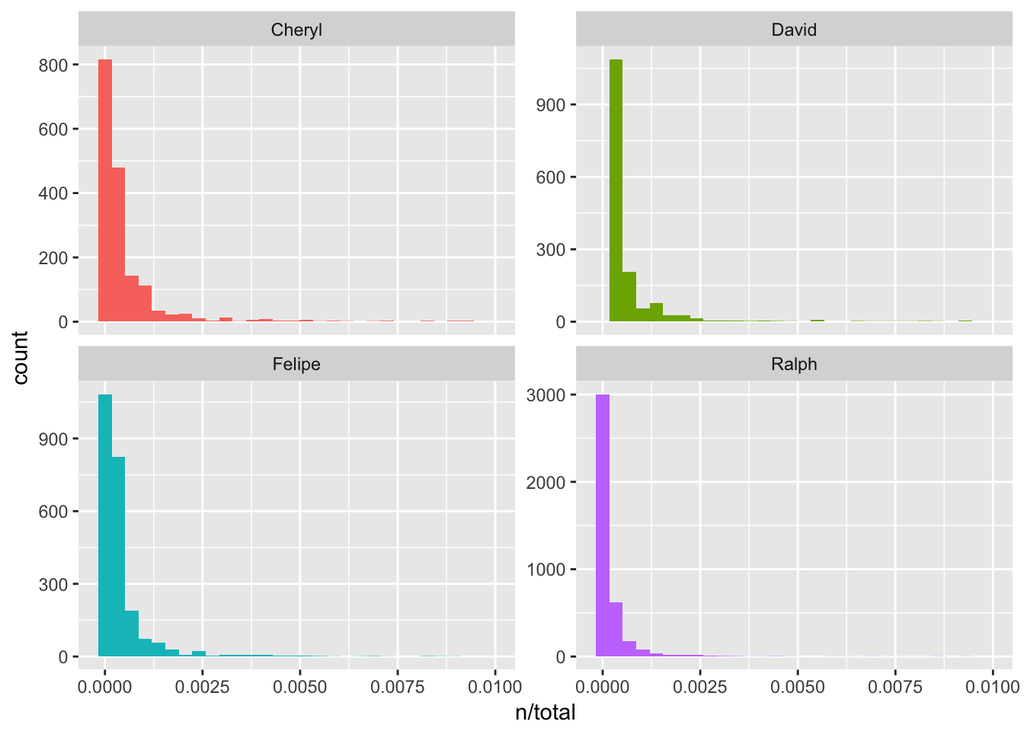

```r
ggplot(author_words, aes(n/total, fill = author)) +
  geom_histogram(show.legend = FALSE) +
  xlim(NA, 0.010) +
  facet_wrap(~author, ncol = 2, scales = "free_y")
```

#### Explore TF-IDF by author

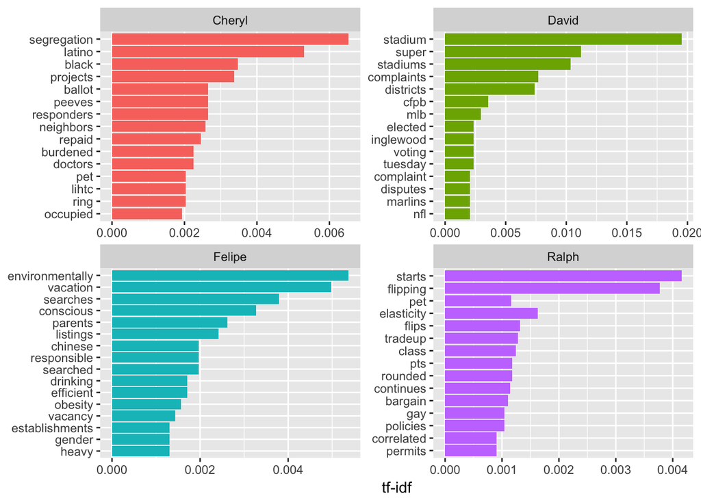

```r
author_words <- author_words %>%
  bind_tf_idf(word, author, n)

plot_author <- author_words %>%
  arrange(desc(tf_idf)) %>%
  mutate(word = factor(word, levels = rev(unique(word))))

plot_author %>%
  group_by(author) %>%
  top_n(15, tf_idf) %>%
  ungroup %>%
  ggplot(aes(word, tf_idf, fill = author)) +
  geom_col(show.legend = FALSE) +
  labs(x = NULL, y = "tf-idf") +
  facet_wrap(~author, ncol = 2, scales = "free") +
  coord_flip()
```

#### Explore sentiment by author

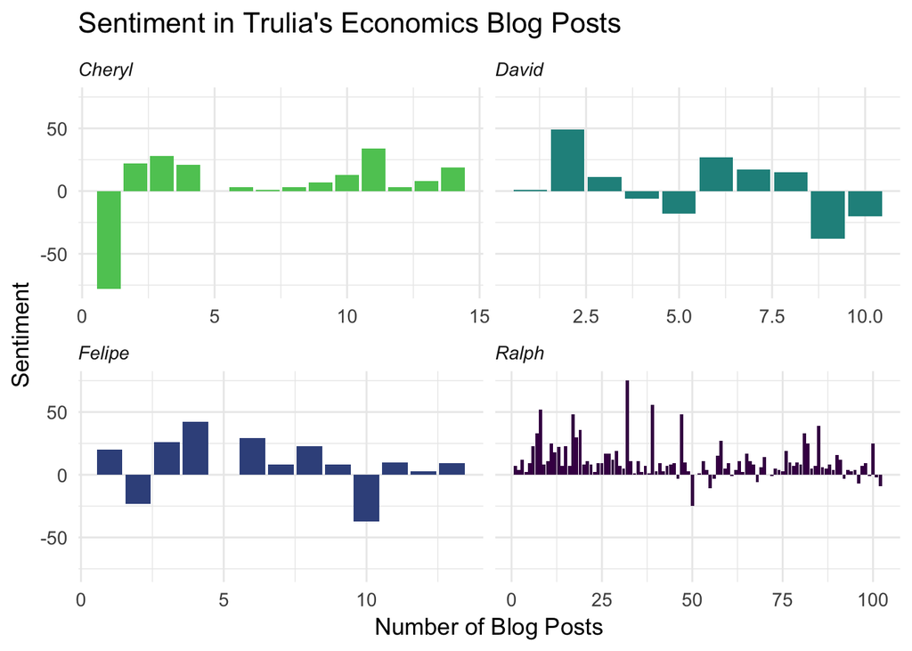

```r
author_sentiment <- tidy_words %>%
  inner_join(get_sentiments("bing"), by = "word") %>%
  count(author, blog_date, sentiment) %>%
  spread(sentiment, n, fill = 0) %>%
  mutate(sentiment = positive - negative) %>%
  # Because dates are so spread out for three out of the four authors,
  # let's switch to post numbers
  arrange(author, blog_date) %>%
  group_by(author) %>%
  mutate(post_number = row_number())

author_sentiment %>%
  ggplot(aes(post_number, sentiment, fill = author)) +
        geom_bar(stat = "identity", show.legend = FALSE) +
        facet_wrap(~author, ncol = 2, scales = "free_x") +
        theme_minimal(base_size = 13) +
        labs(title = "Sentiment in Trulia's Economics Blog Posts",
             y = "Sentiment", x = "Number of Blog Posts") +
        scale_fill_viridis(end = 0.75, discrete = TRUE, direction = -1) +
        theme(strip.text = element_text(hjust = 0)) +
        theme(strip.text = element_text(face = "italic"))
```

### Findings

- If you look at David’s ten posts, he wrote three posts under the category “Home Amenities,” and I suspected these posts in particular would drive his tf-idf scores. It looks like I was right. The three posts in question are about NFL stadiums, school districts, and mortgage complaints, and in David’s top five words by tf-idf are stadium, stadiums, complaints, and districts. Cool.
- I suspected Ralph’s tf-idf scores would be heavily influenced by his “Housing Policy” posts and I was wrong (though “policies” does make the top 15). These four posts in particular are about population growth, Donald Trump, and two about job growth. I don’t see these themes in Ralph’s tf-idf panel. What I do see, however, is that Ralph is relatively unique in that he writes about “housing transactions,” housing starts, flipping houses, and trading-up.
- By category title, Cheryl and Felipe have a similar mix of posts. From this, I suspected they might use similar words. For this prediction my tf-idf chart doesn’t give me what I need. I could go back and do more analysis but this is supposed to be quick and dirty. Felipe wrote about families and grandpa in a couple of his posts and another couple on searches, these two themes describe his panel well. Cheryl’s top words are segregation, latino, black, projects, neighbors, etc., and if you look at her posts “composition of neighborhoods” would be a prominent theme.
- For the sentiment analysis, a significant caveat applies, these are blog posts, not books, so we’re probably not going to be able to pull out a “story arc” in the same way as analysts do for books. I didn’t write this earlier but I could have predicted that sentiment would tend to be mostly positive overall, this is a public facing company blog afterall. David looks to have the highest proportion of “negative” posts and I award the “positive” mantle to Ralph based on sheer post volume and having seven of the ten most “positively rated” posts.